# Emergency Department Trends in Behavioral Health Presentations

BMIN503/EPID600 Final Project

Author

Andi Fu

## 1 Overview

In anticipation of opening CHOP’s first inpatient child and adolescent psychiatric units and Crisis Response Center (CRC) in January 2024, our leadership is interested in having a better, data informed understanding of volume and acuity of behavioral health presentations to the current CHOP emergency rooms in order to better inform staffing.

Faculty that are participating in this project are Weston Geddings, MD, Medical Director of Emergency Psychiatric Services who is overseeing the development of the Crisis Response Center and Joy Payton, Supervisor of Data Education at ARCUS, Department of Biomedical and Health Informatics at Children’s who will be aiding in data extraction and analysis.

## 2 Introduction

Prior to 2017, Philadelphia had two city-designated children’s crisis response centers (CRCs) that children experiencing a psychiatric emergency could present to as walk-ins for support and treatment 24/7. A CRC is also the designated care space that police or EMTs will bring any child under a 302 warrant for emergency psychiatric evaluation that has been approved by the Office of Mental Health. In 2017, both Philadelphia CRCs closed due to issues relating to volume and capacity, and CHOP had to adapt to sudden increased volumes of children presenting to the CHOP Emergency Room with primarily behavioral health and psychiatric emergencies. In addition, during the COVID pandemic which saw increasing mental health needs in the pediatric population, emergency departments everywhere became safety nets for pediatric mental health care. However, the utilization of emergency departments, which typically lack child and adolescent mental health professionals with appropriate treatment spaces and resources, limits appropriate diagnosis, treatment and disposition. These factors contribute to overutilization of inpatient care due to needs for immediate treatment.

Belmont CRC in Philadelphia has since re-opened, however, CHOP has continued to see high volumes of behavioral health emergencies as both CHOP and the city of Philadelphia has recognized that one children’s CRC is not sufficient to meet the needs of the population. In 2022 CHOP submitted and won a bid to open another CRC, and aims to use a trauma informed framework and positive behavioral interventions to guide treatment. This includes having staff on-site who have expertise in recognition and intervention for trauma, including trauma informed care, behavioral intervention for ASD and behavioral disorders, parent interventions, suicide prevention and violence prevention. However, staffing has been an ongoing challenge across numerous hospital systems, and in planning to open this new CRC space and service line, leadership wants to ensure that we not just meet minimal staffing requirements, but that we can plan for appropriate increases in staffing when needed during times of high volume or acuity. Acuity is relevant in that patients that are high acuity and require psychiatric admission and hospitalization typically will need to stay at our facility until we can arrange for transfer to an appropriate psychiatric hospital. In the data analysis below, we will be using whether a patient was recommended for inpatient psychiatric admission as a marker for acuity.

In speaking and working with Dr. Geddings and other emergency room clinicians, it has long been felt that there are trends in the behavioral health volume and acuity presenting to the emergency room depending on time of year as well as time of day, and if we could reliably identify times of high surge we could anticipate increased staffing accordingly to ensure smooth workflow and patient safety since long wait times and increased volumes in an emergency setting can lead to patients leaving without being seen or other unwanted outcomes. In general, the ability to visualize and track this data over time will be useful to operational decision making about resource management. This problem is interdisciplinary given the numerous personnel involved ranging from the current emergency room staff, consulting psychiatrists, clinical social workers, behavioral health technicians, and data analysts.

According to Joy Payton and other data analysts familiar with reporting out emergency room and behavioral health data, there is currently no existing dashboard that offers data visualization for emergency psychiatric presentations that can be analyzed by time and date. Such data availability would be helpful not only in anticipatory staffing, but would allow for longitudinal awareness that could inform needed adjustments in real time.

## 3 Methods

The data used was obtained from the CHOP data warehouse, all data is in the aggregrate and free of PHI. Appropriate tables for Emergency Department visits, psychiatric complaints, diagnoses, length of stay, and disposition were located using CHOP data analytic database tools such as Gene. Data will be extracted using SQL into csv files that will then be loaded into R for cleaning, analysis, and visualization.

Prior to using R, data had to be extracted from numerous tables in CHOP’s CDW.  
Tables used:

ENCOUNTER_ED: This table contains all encounter information from the ED (Emergency Dept)  
BH_DISPOSITIONS_MEDICAL_CLEARANCE: This table contains information about recommended level of behavioral health treatment after evaluation in the ED  
SMART_DATA_ELEMENT_ALL  
MASTER_DIAGNOSIS

The following SQL code will look for distinct visits by visit_key, that are in the BHD table (and therefore seen for psychiatric evaluation and disposition), and return information about those visits in terms of date and times of presentation to the emergency room, length of stay in hours, primary psychiatric diagnosis, and whether they were recommended for inpatient psychiatric care (ED_FIRST_IP_IND), and what level of care they were recommended for overall (ED_DISPO_FIRST). I used data from the past 3 years (2021-now) since 2019-2020 had a lot of anomaly due to Covid pandemic.

SQL code:

SELECT  
DISTINCT bhd.visit_key,  
bhd.ED_DISPO_FIRST,  
bhd.ED_DISPO_FIRST_IP_IND,  
md.dx_id,  
md.dx_nm,  
ed.age_years,  
ed.ed_los_hrs,  
ed.ed_arrival_date  
FROM CHOP_ANALYTICS.ADMIN.BH_DISPOSITIONS_MEDICAL_CLEARANCE bhd  
JOIN CHOP_ANALYTICS.admin.SMART_DATA_ELEMENT_ALL sde ON bhd.VISIT_KEY = sde.VISIT_KEY  
JOIN CDWPRD.admin.MASTER_DIAGNOSIS md ON sde.ELEMENT_VALUE = md.DX_ID  
JOIN CHOP_ANALYTICS.ADMIN.ENCOUNTER_ED ed ON bhd.VISIT_KEY = ed.VISIT_KEY  
AND sde.concept_ID = ‘CHOP#831’  
AND bhd.encounter_date BETWEEN ‘2021-01-01’ AND ‘2023-11-17’

I will load the packages and libraries required, as well as the csv file that resulted from the above SQL query

```r
install.packages("kableExtra")
```

```r
library(dplyr)
library(tidyverse)
library(yardstick)
library(tidymodels)
library(ggplot2)
library(kableExtra)
```

```r
#Load in csv file from above SQL cod
data <- read.csv("bminB2023.csv")

#Clean the data
#Rename columns for ease of use, and drop VISIT_KEY as we will not need it
data<- data |>
    rename(DISPO = ED_DISPO_FIRST ,DATE=ENCOUNTER_DATE,IP_IND = ED_DISPO_FIRST_IP_IND, AGE = AGE_YEARS, LOS = ED_LOS_HRS,FULLDATE = ED_ARRIVAL_DATE) |>
    select(-VISIT_KEY)

#Drop rows where IP_IND is null as it means there was no discharge indicated from the encounter
  data <- data |> filter(!is.na(IP_IND))
```

Now I need to manipulate my date columns since both read in as chr type and I need them to be date types. In addition, I need to extract the hour from my FULLDATE column since that’s the element I”m interested in, and I want to create another column with day of the week given the encounter date.

```r
#From the column FUllDATE which is the date and time, extract just the hour
data <- data |>
      mutate(
        FULLDATE_datetime = mdy_hm(FULLDATE),  # Convert to datetime
        HOUR = hour(FULLDATE_datetime)  # Extract hour
      )
#Convert DATE from chr to date format, then make a new column to tell us day of the week
data <- data |>
   mutate(DATE = mdy(DATE))|>
    mutate(
        DAY = wday(DATE, label = TRUE) # Extract day of the week
      )
```

Now that I have the columns I want in the right formats, I will try to answer some questions I have regarding trends in Behavioral Health presentations to the Emergency Room.

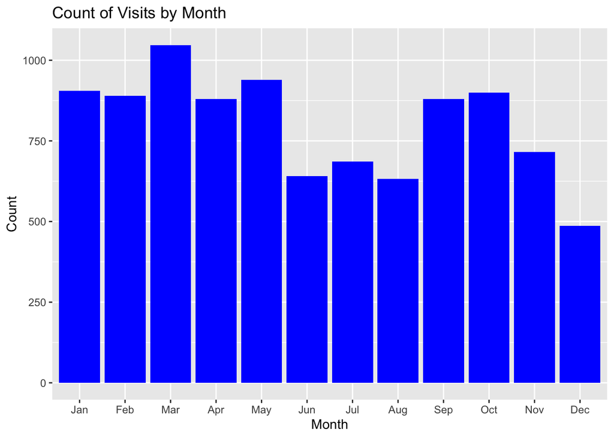

```r
#Visit volume by Month
VisitsByMonth <- data |>
  mutate(month = lubridate::month(DATE, label = TRUE, abbr = TRUE)) |>
  group_by(month) |>
  summarize(count = n())

ggplot(VisitsByMonth, aes(x = month, y = count)) +
  geom_bar(stat = "identity", fill = "blue") +
  labs(title = "Count of Visits by Month", x = "Month", y = "Count")
```

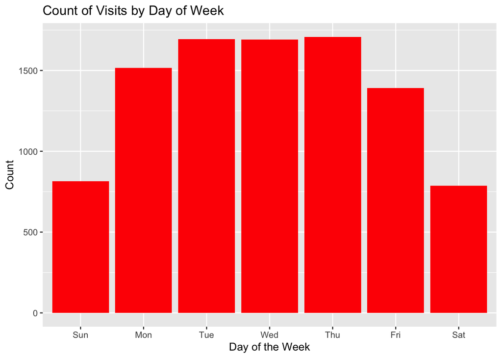

```r
#Visit volume by Day of the week
VisitsByDay <- data |>
  group_by(DAY) |>
  summarize(count = n())

ggplot(VisitsByDay, aes(x = DAY, y = count)) +
  geom_bar(stat = "identity", fill = "red") +
  labs(title = "Count of Visits by Day of Week", x = "Day of the Week", y = "Count")
```

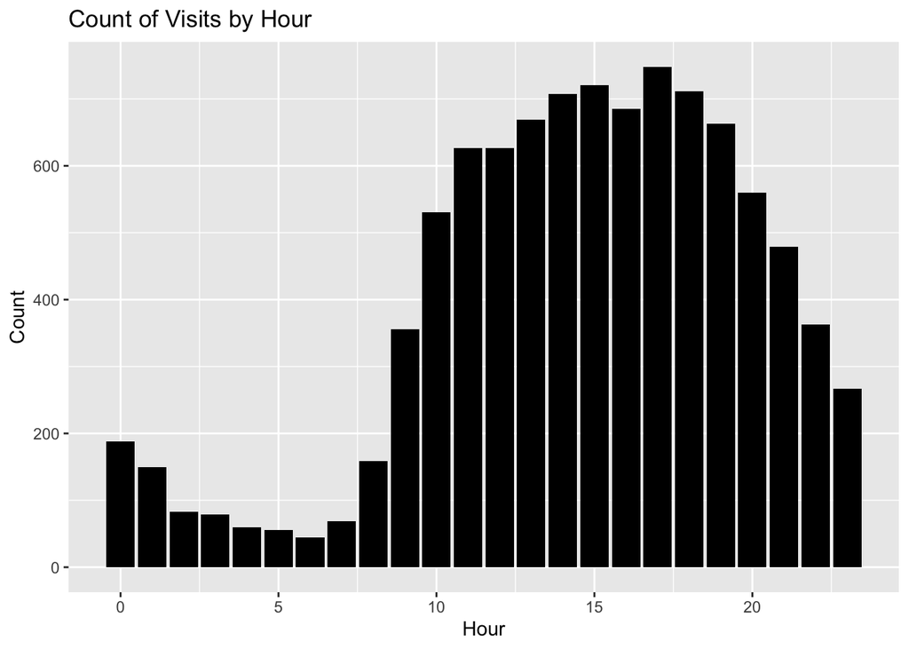

```r
#Visit volume by Hour
VisitsByHour <- data |>
  group_by(HOUR) |>
  summarize(count = n())

ggplot(VisitsByHour, aes(x = HOUR, y = count)) +
  geom_bar(stat = "identity", fill = "black") +
  labs(title = "Count of Visits by Hour", x = "Hour", y = "Count")
```

Are the number of visits significantly different depending on month, day of week, or hour?

```r
#By Month
pMonth <- chisq.test(VisitsByMonth$count, VisitsByMonth$month)
print(pMonth)
```

```
    Pearson's Chi-squared test

data:  VisitsByMonth$count and VisitsByMonth$month
X-squared = 120, df = 110, p-value = 0.2421
```

```r
#By Day of Week
pDay <- chisq.test(VisitsByDay$count, VisitsByDay$DAY)
print(pDay)
```

```
    Pearson's Chi-squared test

data:  VisitsByDay$count and VisitsByDay$DAY
X-squared = 42, df = 36, p-value = 0.227
```

```r
#By hour
pHour <- chisq.test(VisitsByHour$count, VisitsByHour$HOUR)
print(pHour)
```

```
    Pearson's Chi-squared test

data:  VisitsByHour$count and VisitsByHour$HOUR
X-squared = 528, df = 506, p-value = 0.2411
```

Now I would like to look at acuity which will be represented by recommendations for inpatient psychiatric hospitalizations as being of high acuity.

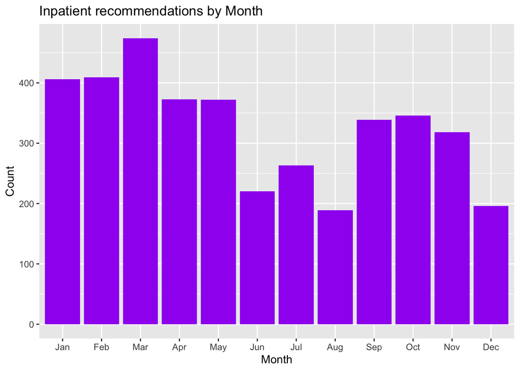

```r
#Acuity by Month, Day, Hour

#Acuity volume by Month
# Group data by month and summarize the count of admitted patients
IPByMonth <- data |>
  mutate(month = lubridate::month(DATE, label = TRUE, abbr = TRUE)) |>
  group_by(month) |>
  summarize(count = sum(IP_IND))

ggplot(IPByMonth, aes(x = month, y = count)) +
  geom_bar(stat = "identity", fill = "purple") +
  labs(title = "Inpatient recommendations by Month", x = "Month", y = "Count")
```

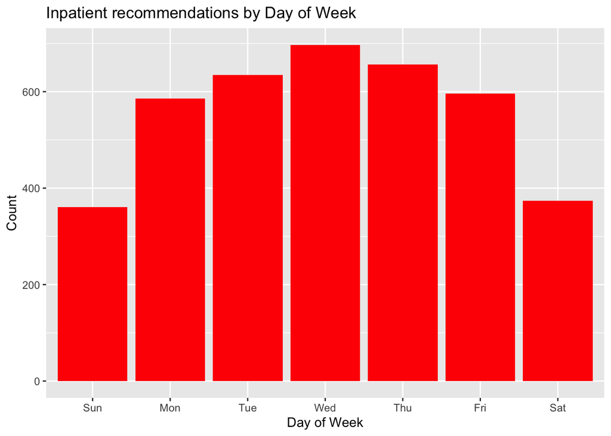

```r
#Acuity volume by Day
# Group data by day of week and summarize the count of admitted patients
IPByDay <- data |>
  group_by(DAY) |>
  summarize(count = sum(IP_IND))

ggplot(IPByDay, aes(x = DAY, y = count)) +
  geom_bar(stat = "identity", fill = "red") +
  labs(title = "Inpatient recommendations by Day of Week", x = "Day of Week", y = "Count")
```

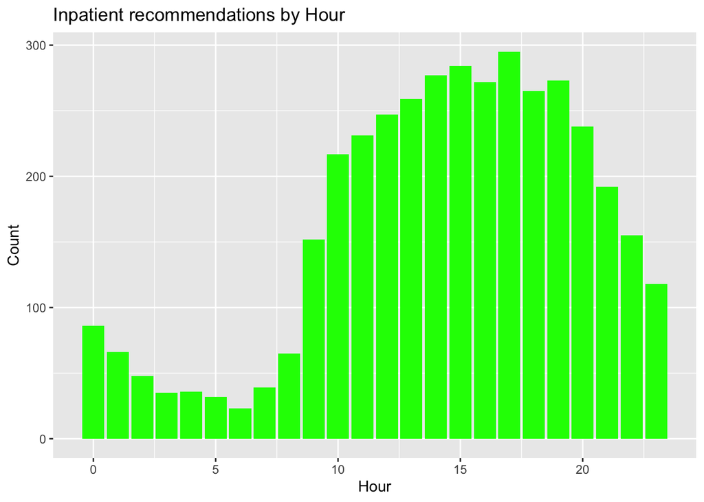

```r
#Acuity volume by Hour
# Group data by day of week and summarize the count of admitted patients
IPByHr <- data |>
  group_by(HOUR) |>
  summarize(count = sum(IP_IND))

ggplot(IPByHr, aes(x = HOUR, y = count)) +
  geom_bar(stat = "identity", fill = "green") +
  labs(title = "Inpatient recommendations by Hour", x = "Hour", y = "Count")
```

Are we getting busier through the years?

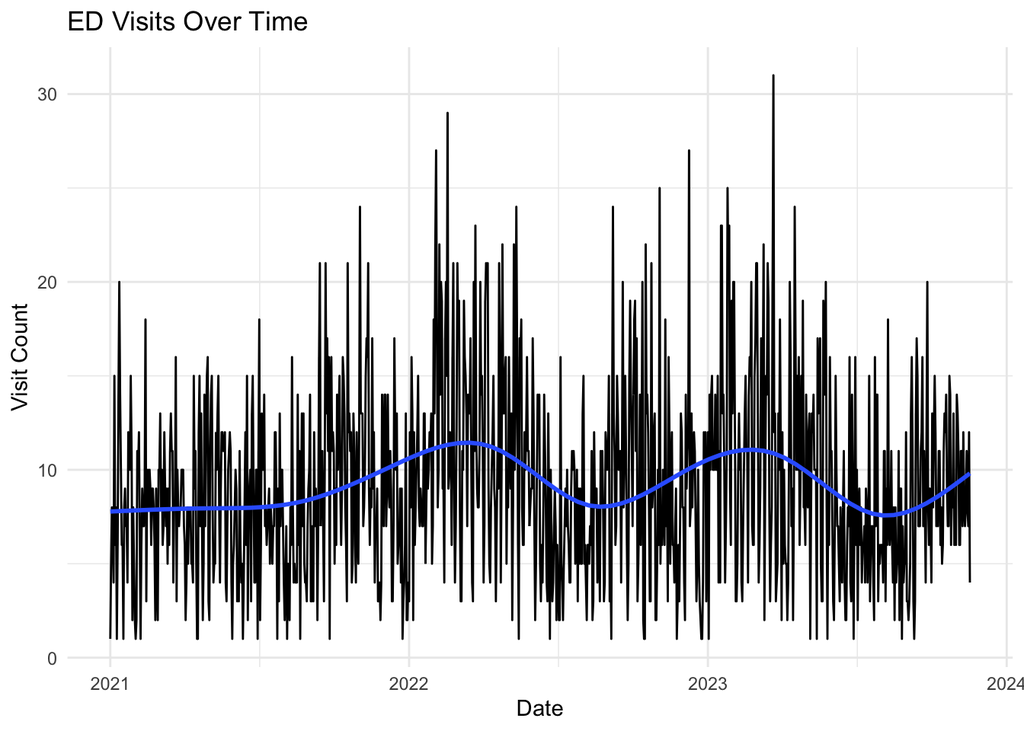

```r
# Pre-calculate the visit counts by DATE
data_summary <- data |>
  group_by(DATE) |>
  summarize(Visit_Count = n())

#Plot over time
OverTime <-ggplot(data_summary, aes(x = DATE, y = Visit_Count)) +
  geom_line() +
  geom_smooth(se = FALSE) +
  labs(title = "ED Visits Over Time", x = "Date", y = "Visit Count") +
  theme_minimal()
print(OverTime)
```

```r
# Group the data by month and summarize visit counts
dataMonth <- data |>
  group_by(YearMonth = format(DATE, "%Y-%m")) |>
  summarize(Visit_Count2 = n())

dataMonth |>
  kable() |>
  kable_styling()
```

| YearMonth | Visit_Count2 |
| --- | --- |
| 2021-01 | 232 |
| 2021-02 | 197 |
| 2021-03 | 277 |
| 2021-04 | 236 |
| 2021-05 | 264 |
| 2021-06 | 204 |
| 2021-07 | 260 |
| 2021-08 | 192 |
| 2021-09 | 301 |
| 2021-10 | 304 |
| 2021-11 | 307 |
| 2021-12 | 241 |
| 2022-01 | 290 |
| 2022-02 | 392 |
| 2022-03 | 387 |
| 2022-04 | 348 |
| 2022-05 | 346 |
| 2022-06 | 230 |
| 2022-07 | 208 |
| 2022-08 | 228 |
| 2022-09 | 319 |
| 2022-10 | 304 |
| 2022-11 | 253 |
| 2022-12 | 245 |
| 2023-01 | 384 |
| 2023-02 | 301 |
| 2023-03 | 383 |
| 2023-04 | 296 |
| 2023-05 | 329 |
| 2023-06 | 207 |
| 2023-07 | 218 |
| 2023-08 | 212 |
| 2023-09 | 260 |
| 2023-10 | 291 |
| 2023-11 | 156 |

Exploring the diagnoses that most commonly present, and most common dispositions.

```r
#Explore diagnoses
diagnosis_summary <- table(data$DX_NM)
diagnosis_summary <- as.data.frame(diagnosis_summary)
d_sorted <- diagnosis_summary |>
  arrange(desc(Freq))
top_20DX <- head(d_sorted, 20)

top_20DX <- top_20DX |>
  rename(Diagnosis = Var1)
top_20DX <- top_20DX |>
  mutate(Percentage = round((Freq / 9602) * 100))


top_20DX |>
  kable() |>
  kable_styling()
```

| Diagnosis | Freq | Percentage |
| --- | --- | --- |
| Depression, unspecified depression type | 1236 | 13 |
| Depression | 668 | 7 |
| Anorexia nervosa, restricting type | 628 | 7 |
| Autism spectrum disorder | 458 | 5 |
| Attention deficit hyperactivity disorder (ADHD), unspecified ADHD type | 330 | 3 |
| Anxiety | 282 | 3 |
| Childhood autism | 224 | 2 |
| Anorexia nervosa, binge eating/purging type | 198 | 2 |
| Autism | 189 | 2 |
| PTSD (post-traumatic stress disorder) | 184 | 2 |
| ADHD | 152 | 2 |
| Oppositional defiant disorder | 144 | 1 |
| Eating disorder, unspecified | 122 | 1 |
| Psychosis, unspecified psychosis type | 118 | 1 |
| Anxiety disorder, unspecified | 102 | 1 |
| Depression, unspecified | 102 | 1 |
| Severe episode of recurrent major depressive disorder, without psychotic features | 94 | 1 |
| Avoidant-restrictive food intake disorder (ARFID) | 93 | 1 |
| Suicidal ideation | 88 | 1 |
| MDD (major depressive disorder) | 87 | 1 |

```r
#Explore dispositions
dispo_summary <- table(data$DISPO)
dispo_summary <- as.data.frame(dispo_summary)
dispo_sorted <- dispo_summary |>
  arrange(desc(Freq))
top_10dispo <- head(dispo_sorted, 10)

top_10dispo <- top_10dispo |>
  rename(Disposition = Var1) |>
  mutate(Percentage = round((Freq / 9602) * 100))

top_10dispo |>
  kable() |>
  kable_styling()
```

| Disposition | Freq | Percentage |
| --- | --- | --- |
| Inpatient mental health hospitalization | 3845 | 40 |
| Deferred | 1401 | 15 |
| Partial hospitalization referral | 1053 | 11 |
| Other | 1051 | 11 |
| Eating Disorder Referral | 707 | 7 |
| Outpatient therapy referral | 583 | 6 |
| Outpatient psychiatry referral,Outpatient therapy referral | 210 | 2 |
| Children's Movile Intervention Services | 143 | 1 |
| None | 121 | 1 |
| Outpatient psychiatry referral | 84 | 1 |

Looking at length of stay in hours

```r
#Statistics for length of stay in hours
summaryLOS <- summary(data$LOS)
print(summaryLOS)
```

```
   Min. 1st Qu.  Median    Mean 3rd Qu.    Max.
  0.450   5.067   6.983  11.473  10.649 404.150
```

## 4 Results and Limitations

The above results show some variations in volume trends that could inform staffing and the times of day and week that may benefit from the ability to have additional staff to address increase in volume.

Based on the Volume graphs, it would seem that Monday-Friday sees higher volumes than the weekend, especially during the hours of 11am to 7pm. It would also seem that June, July, August and December tend to be months that see lower volumes, which is likely related to those months correlating to summer and winter breaks from school. It is not surprising given that school is often cited as a major stressor that drives depression in children (relating to school work load, grades, bullying, and social stressors) and given that various forms of depression are the most common diagnoses driving presentations.

In attempting to do a chi-squared to say if certain times are statistically significant in their volume differences, the results were negative. However, given that this data analysis is meant to inform workflow and staffing, it may not matter whether there was statistical significance as the trend seems quite robust, which is often enough to persuade folk to err on decisions that will minimize harm, which in this case would be to plan for increased staffing during peak volume times.

Further limitations include that CHOP has never operated a CRC, and so volumes seen in our emergency room may not accurately reflect what volume is like to a designated CRC (these are often very busy clinical spaces). Many of our presentations currently tend to be patients already seen at CHOP, and so we may be underestimating volume once we are open as a city designated CRC which is identified as the resource that law enforcement and mobile crisis teams often refer patients to.

## 5 Discussion and Conclusion

Based on the results I would suggest we have 1.5x level staffing of behavioral health evaluators and psychiatrists for 11am-7pm on Monday through Friday, January through May, and September through November. However, realistically, staffing availability is it’s own limiting factor much of the time, especially when it involves a space that needs to be staffed 24/7. We may not have the luxury of increasing staffing over all peak hours, and may need to further narrow the times that represent the times of highest volume and prioritize those shifts. The data above would also lead me to recommend that we have 8 hour shifts rather than 12 hour shifts, as that would allow for a 8am - 4pm, a 4pm - midnight, and an overlapping 11am-7pm shift that can be filled with moonlighting (the term generally used to describe volunteer overtime for clinical roles) during those peak times.

Currently it’s unclear how to use our data regarding length of stay as much of the current length of stay is also related to emergency room and medical workflows that will be absent from the CRC space which should make our length of stays shorter overall. In general it’s a good metric to track since often time interventions aimed to optimize workflows will use length of stay since volume of presentations is often not something under our control. Similarly, tracking dispositions and the percent of patients we are able to discharge from the CRC is also often used as a useful metric for QI projects since we are occasionally able to offer interventions that can lower acuity while in the emergency setting.